# Module 1 Project: How Long Is a Perch?

# The setting

The University of Helsinki recorded 159 fish caught in lake Laengelmavesi, including 56 perch. We will model the **length of a perch** (the `length1` measurement, in cm).

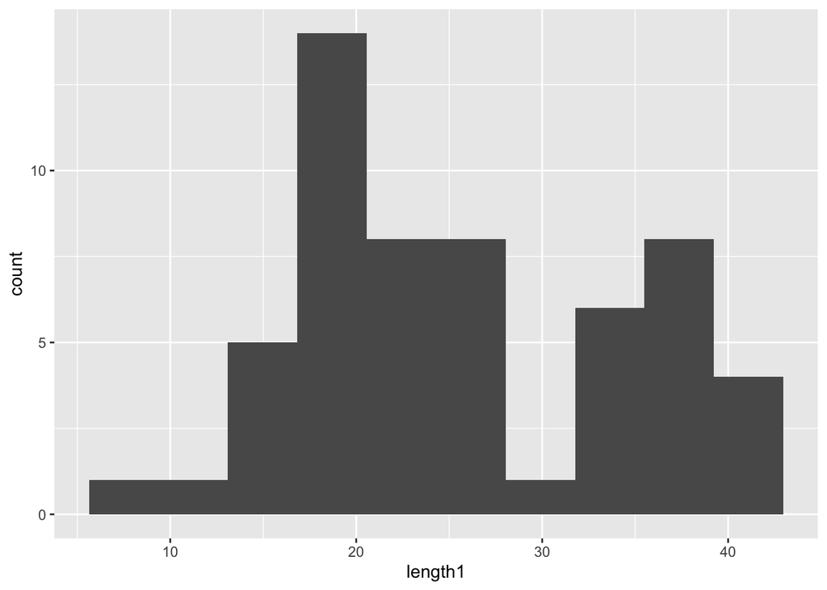

```r
fish <- read.csv("../../data/fish.csv")
perch <- filter(fish, species == 7)
ggplot(perch, aes(x = length1)) + geom_histogram(bins = 10)
```

Our model for perch length is supported on $[0, \theta]$, with $\theta = 50$ cm taken as the largest a perch could plausibly be:

**The model**: a **scaled Beta**: $X = 50 B$ with $B \sim \text{Beta}(4, 4)$, so the density is
$$f(x) = \frac{1}{50} \, f_B(x / 50),
\quad 0 \le x \le 50,$$
where $f_B$ is the Beta(4, 4) density. In general the Beta$(\alpha, \beta)$ density on $[0, 1]$ is
$$f_B(u) = \frac{1}{\mathrm{B}(\alpha, \beta)}\,
u^{\alpha - 1} (1 - u)^{\beta - 1}, \qquad 0 \le u \le 1,$$
where $\mathrm{B}(\alpha,\beta) = \Gamma(\alpha)\Gamma(\beta)/\Gamma(\alpha+\beta)$ is the **beta function** — whatever constant makes the thing integrate to one. It does not depend on $u$, which is why it drops out of most of what follows and matters in exactly one place, C.2.

With $\alpha = \beta = 4$ the density is symmetric, with its peak at 25 cm:

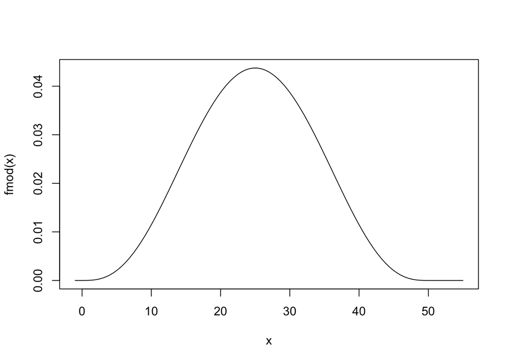

```r
fmod <- function(x) { dbeta(x / 50, 4, 4) / 50 }
curve(fmod(x), from = -1, to = 55)
```

The shape parameter here is a *guess*, not a fact. Part C estimates it from the data and Part D builds a confidence interval for it, so by the end you will know how much of a guess it was.

Reminder: this document will be used on the exam. For any question make sure to display any requested output. If you use any AI assistance in implementing the R code, be prepared to explain how the implementation works.

# Part A: Monte Carlo integration

## A.1

Let $B$ be any random variable with CDF $F_B$ and density $f_B$, and let $X = 50 B$. **Prove** that
$$F_X(x) = F_B(x / 50) \qquad \text{and}
\qquad
f_X(x) = \frac{1}{50} f_B(x / 50).$$

Then **compute** the exact $F(20) = P(X \le 20)$ using `pbeta`. We will treat this as the exact value for the rest of the project.

## A.2

Now estimate the same quantity by Monte Carlo, pretending A.1 were not available:
$$F(20) = \int_0^{20} f(x) \,
dx = \text{E}\left(20 f(V)\right), \quad V \sim U(0, 20).$$

Use 10,000 uniform draws. Report the estimate and a 95% confidence interval from `t.test`.

## A.3

Estimate the model’s mean perch length,
$$\text{E}\left(X\right) = \int_0^{50} x f(x) \,
dx,$$
with a $U(0, 50)$ envelope and 10,000 draws. Report a 95% confidence interval and check against numerical integration:

```r
integrate(function(x) x * fmod(x), 0, 50)
```

```
## 25 with absolute error < 2.8e-13
```

The model is symmetric about 25, so $\text{E}\left(X\right)$ is also available exactly in one line. Give it, and set all three numbers side by side.

## A.4

Compare model to data: report the exact model probability $F(20)$ from A.1 next to the observed fraction of the 56 perch with `length1` $\le 20$.

# Part B: variance reduction

## B.1

Antithetic variables for the A.2 estimator. The model has its mode at 25, so on $[0, 20]$ the density $f$ is strictly increasing (show this with a plot or a one-line argument), and therefore $h(v) = 20 f(v)$ is monotone and the pairs $(V, 20 - V)$ are negatively correlated.

Re-estimate $F(20)$ using 5,000 uniform draws $V_i$ paired with their antithetic partners $20 - V_i$ (10,000 function evaluations total, same as A.2). Report the estimate, the estimated variance of this estimator and of the A.2 estimator, and the percent variance reduction.

## B.2

Importance sampling for $\text{E}\left(X\right)$. The $U(0, 50)$ envelope in A.3 ignores where $x f(x)$ puts its mass. Consider envelopes of the form $Y = 50 B'$ with $B' \sim \text{Beta}(\alpha, \beta)$, which by A.1 has density $g(y) = \frac{1}{50}\,\texttt{dbeta}(y/50, \alpha, \beta)$ on $[0, 50]$ — the uniform is the special case $\alpha = \beta = 1$.

Propose **two** candidate $(\alpha, \beta)$ pairs with small integer values. Useful facts: a Beta($\alpha, \beta$) with $\alpha, \beta > 1$ has its mode at $(\alpha - 1)/(\alpha + \beta - 2)$, and plotting candidates against the target is the way to choose:

```r
curve(x * fmod(x), from = 0, to = 50)
curve(K * dbeta(x / 50, alpha, beta) / 50, add = TRUE, col = "red")
## pick K so the two curves have comparable height
```

For each candidate (10,000 draws each), estimate $\text{E}\left(X\right)$ and the variance of the estimator, and compare with the uniform envelope of A.3.

One choice of small integers $(\alpha, \beta)$ turns out to be **perfect**: every weighted value $y \, f(y) / g(y)$ is the same number. Find it (the mode-matching hint leads straight there), and verify by printing the `range()` of your weighted values. Compare session exercise 3(e).

## B.3

Using the estimated variance of your best **non-perfect** envelope from B.2, compute the number of draws needed for a 95% confidence interval for $\text{E}\left(X\right)$ with width at most $0.1$ cm. Then run it once with that $n$ and report the realized interval and its width.

# Part C: Monte Carlo for estimation

Sampling from the model is one line — scale draws from `rbeta`:

```r
rmod <- function(n) { 50 * rbeta(n, 4, 4) }
```

So far $\text{Beta}(4,4)$ was handed to you. Now we estimate it. Keep the upper limit $\theta = 50$ fixed and keep the symmetry, so the model has a **single unknown parameter** $a$:
$$X = 50 B,
\qquad B \sim \text{Beta}(a, a).$$
Our working model is the case $a = 4$.

## C.1

**Method of moments.** Using $\text{Var}\left(B\right) = \frac{\alpha\beta}{(\alpha+\beta)^2(\alpha+\beta+1)}$, show that
$$\text{Var}\left(X\right) = \frac{625}{2a +
1},$$
and hence that setting $\text{Var}\left(X\right) = S^2$ and solving gives
$$\tilde a =
\frac{1}{2}\left(\frac{625}{S^2} - 1\right).$$
Compute $\tilde a$ for the 56 perch.

Note there is no second equation to solve: $\text{E}\left(X\right) = 25$ for every $a$, so the mean carries no information about the parameter and the variance has to do all the work.

## C.2

**Maximum likelihood.** Here the beta function finally earns its keep. Setting $\alpha = \beta = a$ in the density from the setting,
$$f_B(u) = \frac{1}{\mathrm{B}(a, a)}\, u^{a - 1}
(1 - u)^{a - 1},$$
and dividing by 50 for the scaling (A.1), gives the model’s density. With $u_i = x_i / 50$, show that the log-likelihood is
$$\ell(a) = -n \log 50 - n \log \mathrm{B}(a,a)
+ (a - 1) \sum_{i=1}^n \left[\log u_i + \log(1 - u_i)\right],$$
where $\mathrm{B}$ is the beta function (`beta()` in R, `lbeta()` for its log). Conclude that the data enters **only** through the single number $T = \sum_i [\log u_i + \log(1-u_i)]$.

Unlike the $U(0,\theta)$ maximum in video 3, this likelihood is smooth in $a$, so here you may differentiate. Either solve $\ell'(a) = 0$ numerically with `uniroot` (you will need $\frac{d}{da}\log\Gamma(a) = \psi(a)$, which is `digamma()` in R), or maximize $\ell$ directly with `optimize`. Report $\hat a$ and compare it with $\tilde a$ from C.1.

## C.3

Now pretend we do not know $F(20)$ and must estimate it from a sample of $n = 56$. Two estimators:

- **ECDF**: $\hat F(20) = \frac{1}{56} \sum_i \mathbf{1}(X_i \le 20)$
- **Plug-in**: estimate $a$ by the method of moments from C.1, then use the exact CDF form from A.1: `pbeta(20/50, atilde, atilde)`.

Simulate the sampling distribution of each: 1,000 replications of samples of size 56 from the model ($a = 4$). Using the exact $F(20)$ from A.1, estimate the **bias** and **MSE** of each, with a 99% confidence interval, and show a side-by-side boxplot.

## C.4

Repeat the comparison at $n = 14$ and $n = 224$. Present bias, variance, and MSE for both estimators at all three sample sizes in one table.

## C.5

The $t$ confidence interval is exact only for Normal data, and the model is not Normal. Estimate its true coverage: simulate 10,000 samples of size 56 from the model, compute the nominal 95% `t.test` interval for $\text{E}\left(X\right)$ in each, and report the proportion covering the true value (from A.3), with a 99% confidence interval for that proportion (`binom.test`).

# Part D: Monte Carlo for testing

Part C estimated $a$. Now we **test** it. Throughout, $H_0$ says the perch follow our working model,
$$H_0: \; X = 50B, \quad B \sim
\text{Beta}(4, 4),$$
with $n = 56$, and the alternatives are other values of $a$.

Two statistics:

- **Moment statistic** $T_S = S^2$, the sample variance. Under the model the variance is $625/(2a + 1)$ from C.1, so $T_S$ is a direct read on $a$.
- **Distance statistic** $T_K$, the largest gap between the model CDF and the empirical CDF — `ks.test(x/50, "pbeta", 4, 4)$statistic`. It looks at the whole distribution rather than at $a$ in particular.

Neither has a usable table here, which is why we simulate.

## D.1

Simulate the null distribution of each statistic: 10,000 samples of size 56 from the model with $a = 4$.

$T_S$ can be wrong in either direction, so use a **two-sided** region, rejecting when $T_S$ falls below the 2.5% quantile or above the 97.5% quantile. $T_K$ is a distance, so reject only above its 95% quantile. Report all three cutoffs.

## D.2

With **fresh** simulations under $H_0$ (10,000 new replications), estimate the empirical Type I error rate of each region, each with a `binom.test` confidence interval.

## D.3

Power curves. For each $a \in \{2, 2.5, 3, 3.5, \ldots, 8\}$, simulate 1,500 samples of size 56 from $50 \cdot \text{Beta}(a, a)$ and estimate the power of both tests, using the cutoffs from D.1.

Plot the two power curves on one set of axes, with horizontal reference lines at $0.05$ and $0.80$.

## D.4

**(a)** Test $H_0: a = 4$ on the 56 perch lengths using $T_S$. Report the observed $S^2$, its $p$-value in the $(1 + \#)/(B + 1)$ form, and whether the test rejects at the $0.05$ level.

**(b)** Invert that test to get a confidence interval for $a$. For each candidate $a_0$ on a grid from $1.5$ to $8$ in steps of $0.1$:

- simulate the null distribution of $T_S$ under $50 \cdot \text{Beta}(a_0, a_0)$, 2,000 replications;
- keep $a_0$ if the observed $S^2$ falls between the $2.5\%$ and $97.5\%$ quantiles of that distribution.

The kept values form a 95% confidence interval for $a$. Report its endpoints, and plot the grid against the $p$-value with $\tilde a$ from C.1 and the working value $a = 4$ marked.